# Classification

# Classification Notebook

Importing the libraries

```r
library(vioplot)
library(e1071)
library(caret)
library(ggplot2)
library(dplyr)
library(broom)
library(ggpubr)
```

# Loading Data

## Read in the Dataset

Retrieved the data from a kaggle database measuring Heart Arrhythmia in patients

```r
data <- read.csv("C:/Users/Eric/repo/CS-4375-Machine-Learning/Component-2/INCART 2-lead Arrhythmia Database.csv", na.strings="NA", header=TRUE)
```

Make a copy of the data to reduce re-reading the data set

```r
df <- data
```

Printing a basic the Summary of the data set

```r
summary(df)
```

```
    record              type             X0_pre.RR       X0_post.RR       X0_pPeak            X0_tPeak
 Length:175729      Length:175729      Min.   : 49.0   Min.   : 71.0   Min.   :-4.208601   Min.   :-7.9595
 Class :character   Class :character   1st Qu.:153.0   1st Qu.:153.0   1st Qu.:-0.068575   1st Qu.:-0.2381
 Mode  :character   Mode  :character   Median :188.0   Median :188.0   Median :-0.000857   Median :-0.0397
                                       Mean   :197.2   Mean   :197.2   Mean   : 0.039047   Mean   : 0.1177
                                       3rd Qu.:235.0   3rd Qu.:235.0   3rd Qu.: 0.108743   3rd Qu.: 0.2234
                                       Max.   :506.0   Max.   :506.0   Max.   :10.565904   Max.   : 4.6332
    X0_rPeak          X0_sPeak          X0_qPeak        X0_qrs_interval  X0_pq_interval    X0_qt_interval
 Min.   :-7.1132   Min.   :-7.9713   Min.   :-7.11320   Min.   :  0.00   Min.   :  1.000   Min.   :  3.00
 1st Qu.: 0.3298   1st Qu.:-0.9104   1st Qu.:-0.17626   1st Qu.: 14.00   1st Qu.:  4.000   1st Qu.: 25.00
 Median : 0.9055   Median :-0.6347   Median :-0.10549   Median : 17.00   Median :  6.000   Median : 30.00
 Mean   : 0.8567   Mean   :-0.5868   Mean   :-0.17421   Mean   : 17.62   Mean   :  8.714   Mean   : 37.46
 3rd Qu.: 1.4286   3rd Qu.:-0.3504   3rd Qu.:-0.05458   3rd Qu.: 22.00   3rd Qu.: 12.000   3rd Qu.: 44.00
 Max.   : 4.5983   Max.   : 3.8944   Max.   : 3.12903   Max.   :131.00   Max.   :113.000   Max.   :247.00
 X0_st_interval  X0_qrs_morph0      X0_qrs_morph1      X0_qrs_morph2      X0_qrs_morph3     X0_qrs_morph4
 Min.   : 1.00   Min.   :-7.11320   Min.   :-7.11320   Min.   :-7.51305   Min.   :-7.7958   Min.   :-7.9404
 1st Qu.: 6.00   1st Qu.:-0.17626   1st Qu.:-0.12004   1st Qu.:-0.05432   1st Qu.: 0.1241   1st Qu.:-0.1029
 Median : 6.00   Median :-0.10549   Median :-0.02621   Median : 0.23982   Median : 0.6414   Median : 0.1432
 Mean   :11.13   Mean   :-0.17421   Mean   :-0.08403   Mean   : 0.27836   Mean   : 0.6118   Mean   : 0.1665
 3rd Qu.: 8.00   3rd Qu.:-0.05458   3rd Qu.: 0.07186   3rd Qu.: 0.69674   3rd Qu.: 1.1380   3rd Qu.: 0.4625
 Max.   :89.00   Max.   : 3.12903   Max.   : 3.46521   Max.   : 4.08571   Max.   : 4.4986   Max.   : 4.3042
   X1_pre.RR       X1_post.RR       X1_pPeak           X1_tPeak          X1_rPeak           X1_sPeak
 Min.   : 49.0   Min.   : 71.0   Min.   :-1.10302   Min.   :-2.0218   Min.   :-2.39371   Min.   :-3.2696
 1st Qu.:153.0   1st Qu.:153.0   1st Qu.: 0.01095   1st Qu.: 0.2044   1st Qu.:-0.32062   1st Qu.:-0.9343
 Median :188.0   Median :188.0   Median : 0.04446   Median : 0.3190   Median :-0.08507   Median :-0.7451
 Mean   :197.2   Mean   :197.2   Mean   : 0.06245   Mean   : 0.3664   Mean   :-0.11384   Mean   :-0.7524
 3rd Qu.:235.0   3rd Qu.:235.0   3rd Qu.: 0.08618   3rd Qu.: 0.4519   3rd Qu.: 0.10980   3rd Qu.:-0.5643
 Max.   :506.0   Max.   :506.0   Max.   : 7.63177   Max.   : 3.6454   Max.   : 4.06481   Max.   : 2.8227
    X1_qPeak        X1_qrs_interval  X1_pq_interval    X1_qt_interval   X1_st_interval  X1_qrs_morph0
 Min.   :-6.46175   Min.   :  0.00   Min.   :  1.000   Min.   :  4.00   Min.   : 1.00   Min.   :-6.46175
 1st Qu.:-0.32406   1st Qu.:  4.00   1st Qu.:  3.000   1st Qu.: 18.00   1st Qu.: 8.00   1st Qu.:-0.32406
 Median :-0.12467   Median :  5.00   Median :  5.000   Median : 24.00   Median : 9.00   Median :-0.12467
 Mean   :-0.21606   Mean   : 10.59   Mean   :  7.107   Mean   : 28.05   Mean   :10.35   Mean   :-0.21606
 3rd Qu.:-0.02073   3rd Qu.: 15.00   3rd Qu.:  8.000   3rd Qu.: 33.00   3rd Qu.:12.00   3rd Qu.:-0.02073
 Max.   : 1.38021   Max.   :128.00   Max.   :121.000   Max.   :290.00   Max.   :86.00   Max.   : 1.38021
 X1_qrs_morph1      X1_qrs_morph2      X1_qrs_morph3      X1_qrs_morph4
 Min.   :-4.91330   Min.   :-3.98796   Min.   :-2.96139   Min.   :-3.1321
 1st Qu.:-0.36821   1st Qu.:-0.53684   1st Qu.:-0.67904   1st Qu.:-0.8133
 Median :-0.18547   Median :-0.33999   Median :-0.47761   Median :-0.5922
 Mean   :-0.24779   Mean   :-0.31871   Mean   :-0.38666   Mean   :-0.5396
 3rd Qu.:-0.01321   3rd Qu.: 0.02637   3rd Qu.: 0.05749   3rd Qu.:-0.1722
 Max.   : 2.78418   Max.   : 4.04009   Max.   : 2.77139   Max.   : 2.7649
```

# Filtering the Data

## Remove the unnecessary columns

We remove the record column since we won’t need to differentiate patients

```r
df <- df[, !names(df) %in% c("record")]
```

Looking at the number and type of different arrhythmia we can see that most people have a normal rhythm, but there is a few people with abnormal rhythms.

```r
uniqueTypes <- unique(df$type)
for (type in uniqueTypes) {
  print(paste("The number of rows of type ", type, " is ", nrow(df[df$type == type, ])))
}
```

```
[1] "The number of rows of type  N  is  153546"
[1] "The number of rows of type  VEB  is  20000"
[1] "The number of rows of type  SVEB  is  1958"
[1] "The number of rows of type  F  is  219"
[1] "The number of rows of type  Q  is  6"
```

Remove rows of type SVEB, F, and type Q since there is not enough data to support classifying these types. Want to focus on the difference between normal and VEB

```r
df <- df[df$type == "N" | df$type == "VEB",]
summary(df)
```

```
     type             X0_pre.RR       X0_post.RR       X0_pPeak            X0_tPeak           X0_rPeak
 Length:173546      Min.   : 49.0   Min.   : 71.0   Min.   :-4.208601   Min.   :-7.95946   Min.   :-7.1132
 Class :character   1st Qu.:154.0   1st Qu.:152.0   1st Qu.:-0.068890   1st Qu.:-0.23754   1st Qu.: 0.3236
 Mode  :character   Median :188.0   Median :187.0   Median :-0.001037   Median :-0.03608   Median : 0.9016
                    Mean   :197.8   Mean   :196.3   Mean   : 0.038994   Mean   : 0.12001   Mean   : 0.8545
                    3rd Qu.:236.0   3rd Qu.:234.0   3rd Qu.: 0.108408   3rd Qu.: 0.22579   3rd Qu.: 1.4279
                    Max.   :506.0   Max.   :506.0   Max.   :10.565904   Max.   : 4.63317   Max.   : 4.5983
    X0_sPeak          X0_qPeak        X0_qrs_interval  X0_pq_interval    X0_qt_interval   X0_st_interval
 Min.   :-7.9713   Min.   :-7.11320   Min.   :  0.00   Min.   :  1.000   Min.   :  3.00   Min.   : 1.00
 1st Qu.:-0.9140   1st Qu.:-0.17678   1st Qu.: 14.00   1st Qu.:  4.000   1st Qu.: 25.00   1st Qu.: 6.00
 Median :-0.6376   Median :-0.10570   Median : 17.00   Median :  6.000   Median : 30.00   Median : 6.00
 Mean   :-0.5871   Mean   :-0.17450   Mean   : 17.54   Mean   :  8.696   Mean   : 37.41   Mean   :11.17
 3rd Qu.:-0.3487   3rd Qu.:-0.05497   3rd Qu.: 22.00   3rd Qu.: 12.000   3rd Qu.: 44.00   3rd Qu.: 8.00
 Max.   : 3.8944   Max.   : 3.12903   Max.   :108.00   Max.   :113.000   Max.   :247.00   Max.   :89.00
 X0_qrs_morph0      X0_qrs_morph1      X0_qrs_morph2      X0_qrs_morph3     X0_qrs_morph4       X1_pre.RR
 Min.   :-7.11320   Min.   :-7.11320   Min.   :-7.51305   Min.   :-7.7958   Min.   :-7.9404   Min.   : 49.0
 1st Qu.:-0.17678   1st Qu.:-0.12030   1st Qu.:-0.05453   1st Qu.: 0.1248   1st Qu.:-0.1048   1st Qu.:154.0
 Median :-0.10570   Median :-0.02640   Median : 0.23927   Median : 0.6392   Median : 0.1405   Median :188.0
 Mean   :-0.17450   Mean   :-0.08426   Mean   : 0.27796   Mean   : 0.6110   Mean   : 0.1640   Mean   :197.8
 3rd Qu.:-0.05497   3rd Qu.: 0.07163   3rd Qu.: 0.69544   3rd Qu.: 1.1374   3rd Qu.: 0.4578   3rd Qu.:236.0
 Max.   : 3.12903   Max.   : 3.46521   Max.   : 4.08571   Max.   : 4.4986   Max.   : 4.3042   Max.   :506.0
   X1_post.RR       X1_pPeak           X1_tPeak          X1_rPeak           X1_sPeak          X1_qPeak
 Min.   : 71.0   Min.   :-1.10302   Min.   :-2.0218   Min.   :-2.19031   Min.   :-3.2696   Min.   :-6.46175
 1st Qu.:152.0   1st Qu.: 0.01163   1st Qu.: 0.2037   1st Qu.:-0.31569   1st Qu.:-0.9322   1st Qu.:-0.31907
 Median :187.0   Median : 0.04498   Median : 0.3188   Median :-0.08121   Median :-0.7418   Median :-0.12229
 Mean   :196.3   Mean   : 0.06310   Mean   : 0.3661   Mean   :-0.11006   Mean   :-0.7497   Mean   :-0.21316
 3rd Qu.:234.0   3rd Qu.: 0.08657   3rd Qu.: 0.4520   3rd Qu.: 0.11129   3rd Qu.:-0.5626   3rd Qu.:-0.02008
 Max.   :506.0   Max.   : 7.63177   Max.   : 3.6454   Max.   : 4.06481   Max.   : 2.8227   Max.   : 1.38021
 X1_qrs_interval  X1_pq_interval    X1_qt_interval   X1_st_interval X1_qrs_morph0      X1_qrs_morph1
 Min.   :  0.00   Min.   :  1.000   Min.   :  4.00   Min.   : 1.0   Min.   :-6.46175   Min.   :-4.91330
 1st Qu.:  4.00   1st Qu.:  3.000   1st Qu.: 18.00   1st Qu.: 8.0   1st Qu.:-0.31907   1st Qu.:-0.36390
 Median :  5.00   Median :  5.000   Median : 24.00   Median : 9.0   Median :-0.12229   Median :-0.18194
 Mean   : 10.66   Mean   :  7.124   Mean   : 28.09   Mean   :10.3   Mean   :-0.21316   Mean   :-0.24490
 3rd Qu.: 15.00   3rd Qu.:  8.000   3rd Qu.: 33.00   3rd Qu.:12.0   3rd Qu.:-0.02008   3rd Qu.:-0.01235
 Max.   :128.00   Max.   :121.000   Max.   :290.00   Max.   :86.0   Max.   : 1.38021   Max.   : 2.78418
 X1_qrs_morph2      X1_qrs_morph3      X1_qrs_morph4
 Min.   :-3.98796   Min.   :-2.96139   Min.   :-3.1321
 1st Qu.:-0.53146   1st Qu.:-0.67509   1st Qu.:-0.8096
 Median :-0.33564   Median :-0.47286   Median :-0.5863
 Mean   :-0.31488   Mean   :-0.38230   Mean   :-0.5354
 3rd Qu.: 0.02809   3rd Qu.: 0.05914   3rd Qu.:-0.1682
 Max.   : 4.04009   Max.   : 2.77139   Max.   : 2.7649
```

Factor each of the 2 types to ensure that each has its own value. This will help us ensure that naive bayes recognizes each of these as a number instead a string

```r
df$type <- factor(df$type, levels=c("N", "VEB"))
contrasts(df$type)
```

```
    VEB
N     0
VEB   1
```

# Using the Data

## Splitting the data into train/test

We split the data into 2 separate data frames depending on a random sample. 80 percent of the data is going to training and the other 20 percent is going to testing and evaluation.

```r
dt = sort(sample(nrow(df), nrow(df)*.8))
train <- df[dt,]
test <- df[-dt,]
```

## Data Exploration Functions

Data exploration Function 1 - We can see that there are no NA’s inside of the data frame. This is good for us since all data can be used inside our linear models and we don’t need to worry about replacing any values. For the dim function we can see the number of observation times the number of columns

```r
sum(is.na(train))
```

```
[1] 0
```

```r
dim(train)
```

```
[1] 138836     33
```

```r
cor <- cor(df[2:33], use="complete")
cor[cor < .5 & cor > -.5] <- 0
cor[upper.tri(cor, diag = TRUE)] <- 0
table(cor)
```

```
cor
-0.681552879721901 -0.680452238026283 -0.613787819747585  -0.57719425529799 -0.543725476969976 -0.532249558133321
                 2                  1                  1                  1                  1                  2
-0.512725069534083 -0.507848330225606   -0.5011677148133                  0  0.551826345143866  0.557453050090752
                 1                  1                  1                952                  2                  2
 0.569976100807781  0.591670461519874  0.596196766041581  0.599707309780323  0.600555090682228  0.608382978601611
                 1                  1                  1                  1                  1                  1
 0.609816558106336  0.614250894000366  0.615474343462091  0.617395597336139  0.634660909137918  0.636073413766473
                 2                  1                  2                  1                  1                  1
 0.637998375145257  0.656407935313161  0.668954992015978  0.685589309537155  0.687264505644391  0.694347066833005
                 1                  1                  1                  1                  2                  1
 0.708205695359803  0.713006221051641  0.737740642456596  0.753248412246809  0.764116598110986  0.768268176124287
                 1                  2                  1                  1                  2                  1
 0.778110120011753  0.778149876122119  0.784260201927876  0.792273479475908  0.814000721851494  0.840852045732589
                 1                  1                  1                  1                  2                  1
 0.844236520057343  0.845760374105322  0.863353608495156  0.872253699074859  0.873143316095882  0.884628792760613
                 1                  2                  1                  1                  1                  1
 0.886280462017853   0.89714939570761  0.903030549958228  0.928607577815106  0.947014688865174  0.949507110672762
                 1                  1                  1                  1                  2                  1
 0.960574156794689  0.968017171366627                  1
                 1                  2                  4
```

Data Exploration Function 3 - Using the graph on the left we can see there is a very strong imbalance between the number of N’s and VEB’s. Using the graph on the right we can see that even among highly correlated values we may not be able to differentiate between the two types of rhythms. The bottom graph is another example with semi-strong correlation

```r
par(mfrow=c(2,2))

counts <- table(train$type)
barplot(counts, xlab="Heart Rhythm", ylab="Frequency", col=c("red","blue","green"))

plot(train$X1_qrs_morph1, train$X1_qrs_morph2, pch=21, cex=0.75, bg=c("red", "blue", "green")[unclass(df$type)],)
```

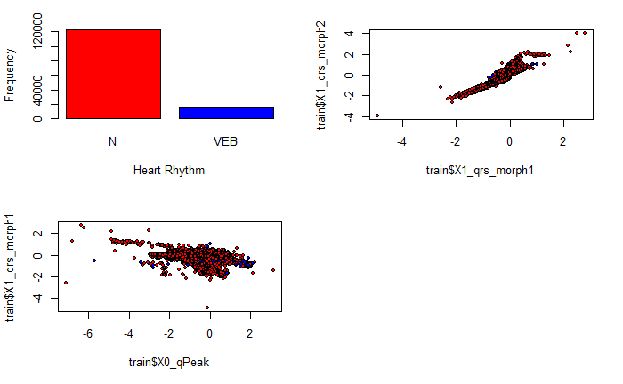

```r
plot(train$X0_qPeak, train$X1_qrs_morph1, pch=21, cex=0.75, bg=c("red", "blue", "green")[unclass(df$type)])
```

Some more basic plot functions for other varied visual confirmation of some correlation.

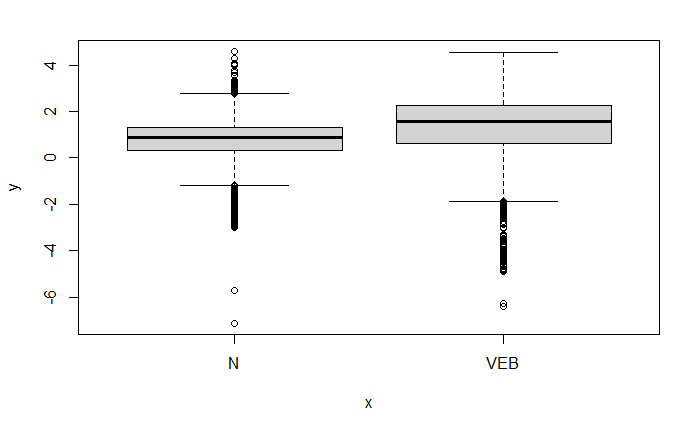

```r
plot(train$type, train$X0_rPeak)
```

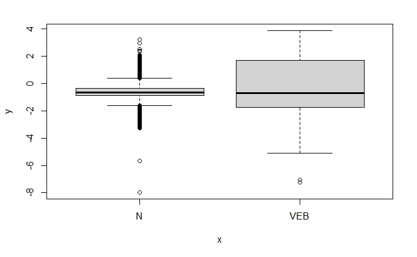

```r
plot(train$type, train$X0_sPeak)
```

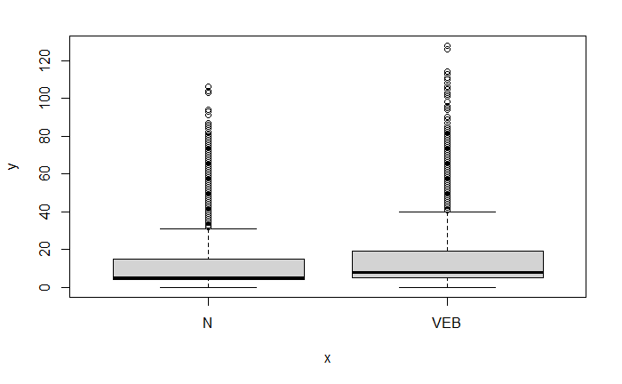

```r
plot(train$type, train$X1_qrs_interval)
```

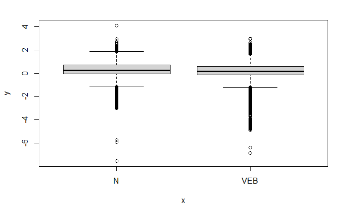

```r
plot(train$type, train$X0_qrs_morph2)
```

## Data Exploration Function 5

cov(train$X1_rPeak, train$X0_rPeak) - shows not a lot of similarity between different X values even in a single patient cov(train$X0_qrs_interval, train$X0_qPeak) - shows high covariance between the intervals length and peaks

```r
cov(train$X1_rPeak, train$X0_rPeak)
```

```
[1] -0.1699659
```

```r
cov(train$X0_qrs_interval, train$X0_qPeak)
```

```
[1] 0.7559834
```

# Informative Graphs

Several plots that show the relationship between different variables while also showing the different circles depending on which type of rhythm the patient had

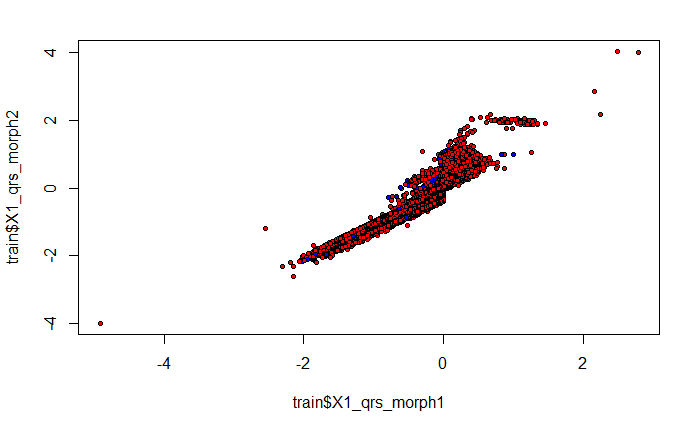

```r
plot(train$X1_qrs_morph1, train$X1_qrs_morph2, pch=21, cex=0.75, bg=c("red", "blue")[unclass(df$type)])
```

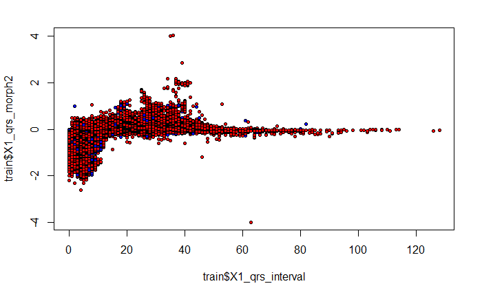

```r
plot(train$X1_qrs_interval, train$X1_qrs_morph2, pch=21, cex=0.75, bg=c("red", "blue")[unclass(df$type)])
```

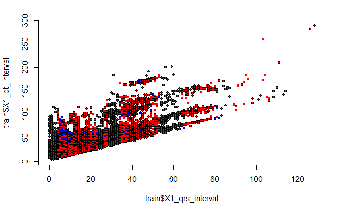

```r
plot(train$X1_qrs_interval, train$X1_qt_interval, pch=21, cex=0.75, bg=c("red", "blue")[unclass(df$type)])
```

## Making Models

```r
func <- function(df){
  dt <- sort(sample(nrow(df), nrow(df)*.8))
  train <- df[dt,]
  test <- df[-dt,]
  glm1 <- glm(type~X0_qPeak, data=train, family="binomial")
  probs <- predict(glm1, newdata=test)
  pred <- ifelse(probs>0.5, 1, 0)
  acc <- mean(pred==test$type)
  print(paste("accuracy = ", acc))
  table(pred, test$type)
}
```

```r
n_data <- df[df$type == "N",]
veb_data <- df[df$type == "VEB",]

func(n_data)
```

```
Warning: glm.fit: algorithm did not converge
```

```
[1] "accuracy =  0"

pred     N   VEB
   0 30710     0
```

```r
func(veb_data)
```

```
[1] "accuracy =  0"

pred    N  VEB
   0    0 4000
```

Makes a naive bayes model that attempts to find the type of rhythm depending on the peak value of a patient. Uses the training data while training. Prints a basic summary of the naive bayes model Naive Byes - shows a table with the conditional probabilities of a certain rhythm happening. We can see that in general once X gets below a certain value there is a much higher chance of the rhythm being VEB

```r
nb1 <- naiveBayes(type~X0_qPeak, data=train)
nb1
```

```
Naive Bayes Classifier for Discrete Predictors

Call:
naiveBayes.default(x = X, y = Y, laplace = laplace)

A-priori probabilities:
Y
        N       VEB
0.8846337 0.1153663

Conditional probabilities:
     X0_qPeak
Y           [,1]      [,2]
  N   -0.1619998 0.3295289
  VEB -0.2629795 0.5671563
```

Uses the predict module to predict for naive Bayes module. This predict uses the test data set to test how effective our model was in predicting the correct result

```r
## Predicting the linear model
resultNaiveBayes <- predict(nb1, newdata = test, type="class")
```

## Evaluate on test data for Naive Bayes

The prediction on the naive bayes algorithm shows that we got an accuracy of about 88 percent. The low kappa value shows that there is a high prevalence oh the number of N’s. If we were to do this again we would want to ensure that the model took more of VEB into consideration. This is further shown with a high sensitivity of 98%. We have a high positive predicted value which makes sense since it predicts the class with the highest number most of the time.

```r
mean(resultNaiveBayes==test$type)
```

```
[1] 0.8810717
```

```r
confusionMatrix(resultNaiveBayes, test$type)
```

```
Confusion Matrix and Statistics

          Reference
Prediction     N   VEB
       N   30173  3574
       VEB   554   409

               Accuracy : 0.8811
                 95% CI : (0.8776, 0.8845)
    No Information Rate : 0.8852
    P-Value [Acc > NIR] : 0.9927

                  Kappa : 0.1263

 Mcnemar's Test P-Value : <2e-16

            Sensitivity : 0.9820
            Specificity : 0.1027
         Pos Pred Value : 0.8941
         Neg Pred Value : 0.4247
             Prevalence : 0.8852
         Detection Rate : 0.8693
   Detection Prevalence : 0.9723
      Balanced Accuracy : 0.5423

       'Positive' Class : N
```

# Strengths and Weaknesses

## Strengths and Weaknesses of Naive Bayes

The strength of Naive Bayes lies in its ability to quickly train on rather small data sets and since it the output of the model is just a single factor it is easy for us to understand the results of the given data. The bias of a given model is also much higher given that the eventual probabilities of the model are based off the population sizes of the the classes in the data. A general weakness is that there is little growth in the abilities of model as data size increases. This is due to the fact that even as more data comes in if the probabilities are the same for the data then the eventual result of the model will not end up changing.

## Strengths and Weaknesses of Logistic Regression

The strength of Logistic Regression is great for data that is easily split by a line. For example if there is a data point that easily divides two or more classes. Then it defines being above that line as one class and below as another. Additionally it is very fast since it is just forming a linear model that splits the two classes. Additionally gives a nice output of predicted classes. The main weakness is that it really struggles if there is no clear boundary between any two predictors. Have to find a predictor that splits the two well down the middle or use a different model